# Adopt Don’t Shop: The State of Adoptable Dogs In The U.S.

By Emma Hill

February 18th, 2022

```r
suppressPackageStartupMessages(library(tidyverse, warn.conflicts = FALSE))
suppressPackageStartupMessages(library(ggplot2, warn.conflicts = FALSE))
suppressPackageStartupMessages(library(tidytuesdayR, warn.conflicts = FALSE))
```

You may have heard the saying “adopt, don’t shop.” For many people, seeing those excruciating ASPCA commercials with the dog chained to a post shivering in the cold, emaciated in a cage, or cowering in the corner of their kennel gives them a vague idea about the value and importance of adoption from shelters or rescues. However, for those who can afford it, the pull of buying “a perfect pup” from a breeder or “window shopping” from those cute faces in a pet shop is still very tempting. Especially with the recent pandemic leading many to seek companionship in the form of a new dog, it is important that future dog owners truly understand the harsh reality of dogs in rescues and shelters within the U.S. before they make this critical decision. In my opinion, if everyone knew the reality of dogs needing adoption, it wouldn’t really be a decision at all.

Using data pulled from PetFinder API for all adoptable dogs in every U.S. state on the single day of September 20th, 2019, we are able to get a sense of the bigger picture, that is the recent state of dogs needing adoption in our country. This picture was an unfortunate total amount of 58,180 dogs (observations) listed as available for adoption. This data set included descriptive information on each dog listed on PetFinder.com on 09/20/2019, including the variables such as breed, color, age, sex, size, location, and many more, thus allowing for the analysis of the many adoptable dogs in our country based on specific characteristics. This data was originally published in an article titled [“Finding Forever Homes”](https://pudding.cool/2019/10/shelters/) on the website “The Pudding Github”, having been collected, cleaned, and story written by Amber Thomas, and design by Sacha Maxim.

Although adopting *any* dog is saving a life, not all dogs are created equal in the eyes of humans, and this sad fact can be represented through looking closer at the population and characteristics of these 58,000 dogs needing adoptions on that single day in September, 2019. In this sense, we can try to answer the question of *what type of dogs are in most need of adoption?*

```r
dog_descriptions <- readr::read_csv('https://raw.githubusercontent.com/rfordatascience/tidytuesday/master/data/2019/2019-12-17/dog_descriptions.csv', show_col_types = FALSE)
```

```r
top_breeds <- dog_descriptions %>%
  filter(breed_primary == "Pit Bull Terrier" | breed_primary == "Labrador Retriever" | breed_primary == "Chihuahua" | breed_primary == "Mixed Breed" | breed_primary == "Terrier" | breed_primary == "Hound" | breed_primary == "German Shepherd Dog" | breed_primary == "Boxer" | breed_primary == "Shepherd" | breed_primary == "American Staffordshire Terrier") %>%
  filter(sex == "Female" | sex == "Male")

top_breeds <- top_breeds %>%
  select(-url, -description)

top_breeds$breed_primary <- factor(top_breeds$breed_primary, levels = c("American Staffordshire Terrier", "Shepherd", "Boxer", "German Shepherd Dog", "Hound", "Terrier", "Mixed Breed", "Chihuahua", "Labrador Retriever", "Pit Bull Terrier"))

top_breeds$age <- factor(top_breeds$age, levels = c("Senior", "Adult", "Young", "Baby"))
```

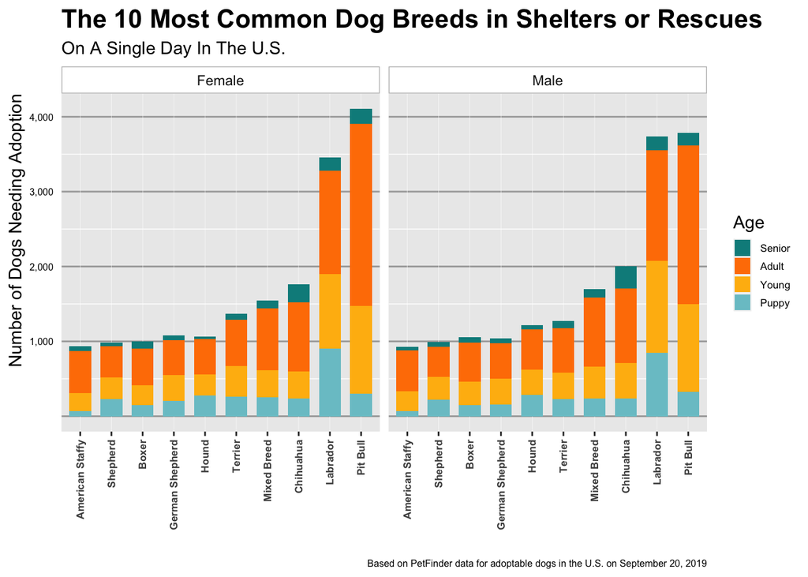

```r
ggplot(top_breeds, aes(x = breed_primary, fill = age)) +
  geom_bar(width = .7) +
  facet_wrap( ~ sex) +
  labs(x = "", y = "Number of Dogs Needing Adoption", fill = "Age", title = "The 10 Most Common Dog Breeds in Shelters or Rescues", subtitle = "On A Single Day In The U.S.", caption = "Based on PetFinder data for adoptable dogs in the U.S. on September 20, 2019") +
  scale_fill_manual(values = c("darkcyan", "darkorange1", "darkgoldenrod1", "cadetblue3"), name = "Age", labels = c("Senior", "Adult", "Young", "Puppy")) +
  scale_x_discrete(breaks = c("American Staffordshire Terrier", "Shepherd", "Boxer", "German Shepherd Dog", "Hound", "Terrier", "Mixed Breed", "Chihuahua", "Labrador Retriever", "Pit Bull Terrier"),
                   labels = c("American Staffy", "Shepherd", "Boxer", "German Shepherd", "Hound", "Terrier", "Mixed Breed", "Chihuahua", "Labrador", "Pit Bull")) +
  scale_y_continuous(breaks = seq(0, 4000, by = 1000),
                     labels = c("", "1,000", "2,000", "3,000", "4,000")) +
  theme(axis.text.x = element_text(angle = 90, hjust = 1, vjust = .5, size = 6.5, face = "bold"),
        axis.text.y = element_text(size = 6, color = "black"),
        plot.title = element_text(size = 16, vjust = 1, face = "bold"),
        strip.background = element_rect(fill = "white", color = "grey"),
        legend.key.size = unit(.4, 'cm'),
        legend.text = element_text(size = 6.5),
        axis.ticks.y = element_blank(),
        panel.grid.major.y = element_line(color = "darkgrey"),
        panel.grid.major.x = element_line(size = .1),
        plot.caption = element_text(size = 6),
        axis.title.y = element_text(hjust = 1)
        )
```

First, in looking at the amount of certain dogs in shelters and rescues, we can try to understand *what breeds are most common*. In the graphic above, we are able to see the top 10 most common breeds of dogs in shelters or rescues on this day in 2019, defined as the breeds with the greatest number of dogs needing adoption. We are then able to see clearly that pit bulls and labradors are the two breeds most represented in shelters or rescues, with the number of dogs for these breeds in rescues or shelters being close to 1,000 or 2,000 than the other top breeds. Further, we are then able to use this graphic to understand how other significant characteristics in adoption, such as age and sex, interact with breed to affect representation at a shelter. Female adult pit bulls are the most common type of dogs needing adoption. Chihuahuas are the most common breed of senior dogs among those shown. However, more generally, it appears that the effect of age is somewhat similar across breeds, with adult dogs being the most common in shelters or rescues. It is also important to note that this data has been split into two separate graphs based on sex, thus if looking to find the total *breed* amount, you simply have to combine the total for both female and male.

This graph also illustrates another important point: four out of the ten most common dogs, including american staffies, boxers, terriers, and pit bulls, are all considered “bully breeds.” This category of dog breeds is notorious for its bad wrap and negative stereotype with the public, with many people falsely assuming all dogs in these breeds are “dangerous,” “violent,” or “unpredictable,” which we can then assume affects the frequency by which they are adopted. However, it is possible that this stereotype and thus effect on adoption may be dependent on location. Thus, by first examining *where in the country has the most adoptable dogs*, and then *how bully breeds are represented* in these states will provide us a greater understanding about the crisis that is bully breeds within rescues and shelters.

```r
dog_descriptions_bully <- dog_descriptions %>%
  mutate(bully_breed = ifelse(breed_primary == "American Staffordshire Terrier" | breed_primary == "Pit Bull Terrier" | breed_primary == "American Bulldog" | breed_primary == "Boxers" | breed_primary == "Terrier" | breed_primary == "Dogo Argentino" | breed_primary == "Cane Corso" | breed_primary == "English Bulldog" | breed_primary == "Mastiff" | breed_primary == "Rotweiler" | breed_primary == "Boston Terrier" | breed_primary == "French Bulldog" | breed_primary == "Staforshire Bull Terrier" | breed_primary == "Bullmastiff" | breed_primary == "Bull Terrier" | breed_primary == "Dogue de Bordeaux"| breed_primary == "Presa Canario" | breed_primary == "Pug" | breed_primary == "Great Dane", T, F))
```

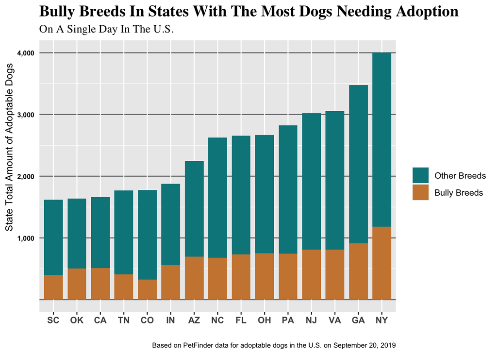

```r
dog_descriptions_bully %>%
  filter(!str_detect(contact_state, "\\d")) %>%
  add_count(contact_state) %>%
  filter(n > 1500) %>%
  ggplot(aes(x = reorder(contact_state, n), fill = bully_breed)) +
    geom_bar(width = .8) +
    scale_fill_manual(values = c("turquoise4", "tan3"), name = "", labels = c("Other Breeds", "Bully Breeds")) +
    labs( y = "State Total Amount of Adoptable Dogs",
          title = "Bully Breeds In States With The Most Dogs Needing Adoption",
          subtitle = "On A Single Day In The U.S.",
          x = "",
          caption = "Based on PetFinder data for adoptable dogs in the U.S. on September 20, 2019") +
    scale_y_continuous(breaks = seq(0, 4000, by = 1000),
                     labels = c("", "1,000", "2,000", "3,000", "4,000")) +
    theme(axis.text.x = element_text(hjust = .5, size = 9, face = "bold"),
        axis.text.y = element_text(size = 7, color = "black", face = "bold"),
        plot.title = element_text(size = 16, face = "bold", family = "Times"),
        plot.subtitle = element_text(family = "Times", size = 11.5),
        panel.grid.major.y = element_line(color = "gray47"),
        axis.ticks.y = element_blank(),
        axis.title.y = element_text(hjust = .78, size = 10),
        plot.caption = element_text(size = 7, vjust = 1.5)
        )
```

In the graph above, the top ranking states in terms of the greatest amount of adoptable dogs (with only those with greater than 1,500 dogs shown) are visualized, in addition to the general proportion by which bully breeds make up the total amount of adoptable dogs. New York appears as the state with the greatest number of dogs needing adoption, with close to 4,000 dogs in total. Furthermore, the Mideast is highly represented at the top of this list, with New York, Virginia, New Jersey, and Pennsylvania making up four out of the top five states with the most amount of dogs in rescues or shelters. We can also see that fairly consistently across each state, bully breeds make up a shocking 1/4 or 1/3 of the total amount of dogs in rescues or shelters. This illustrates that the stereotyping of bully breeds is likely not limited to only certain states, instead with the bad public perception of these dog breeds affecting adoption and breed representation in shelters and rescues across the country.

The decision to use bar graphs to represent this table was due to the fact that almost every variable within this data set was a character variable, thus limiting the options which could be used for visualization. However, the plotting of count was very appropriate for the objective of this data analysis, which overall was to illustrate the issue of the tremendous amount of dogs in shelters and rescues in our country and thus, highlight the importance of adoption for future pet owners. In the first graph, the main focus of the graph was understanding representation (in count) by breed type, which is why I mapped this variable onto the x-axis and thus position and length aesthetic. In looking to visualize the interaction between other characteristics of dogs, I then used facets for the categorical variable of sex, as it only had two levels. For this data, I found that with many facets (and levels) the more nuanced details in the charts seemed to get lost, thus creating only two facets using the variable of sex was quite successful in maintaining clarity. I then mapped age onto color and area (through “fill”) , as I found the utilization of stacked bar charts as much more effective way to illustrate the count of the four levels than using a side-by-side bar chart. In choosing the colors for the age scale, I chose four quite discrete colors that I thought could hold some association with the levels of age. Next, for my second graph, the two main variables which I wanted to highlight were state and breed (but this time limited to the two levels of bully breed and other). I mapped the variable of state onto the x-axis and thus position and length, in order to plot the total amount of dogs per state. I then mapped the variable of breed onto color and area (through “fill), as once more, the amount of categorical levels I included for the x-axis made it more effective to use a stacked bar chart to illustrate the count of bullies breeds verses other breeds, than to use side-by-side bars. I also reordered the x-axis, so that it was sorted by ascending count instead of alphabetical to further highlight which states had the most amount of dogs needing adoption. Finally, I chose these two discrete colors for my scale as I found them to be visually appealing, as well as draw the reader’s eyes to the area fill of the bars, specifically the proportion of bully breeds.

[GitHub Source: Amber Thomas](https://github.com/the-pudding/data/blob/master/dog-shelters/README.md)

Data from PetFinder API.